# Base Plotting in **R**: Part III

[EFB 654: R and Reproducible Research](https://eligurarie.github.io/EFB654/)

Elie Gurarie

February 18, 2026

# Goal:

- Layouts (`mfrow` and `layout`)
- Exporting figures (`png`, `pdf`, `jpg` and in Makdown)
- Brief intro to `ggplot`

Using the World Development Indicators data from the last lab

```r
wdi <- read.csv("WDI.csv")
wdi$region <- factor(wdi$region)
cols <- c("East Asia & Pacific"        = "steelblue",
          "Europe & Central Asia"      = "forestgreen",
          "Latin America & Caribbean"  = "goldenrod",
          "Middle East & North Africa" = "darkorange",
          "North America"              = "mediumpurple",
          "South Asia"                 = "firebrick",
          "Sub-Saharan Africa"         = "sienna")
```

Recall:

```r
str(wdi)
```

```
## 'data.frame':    208 obs. of  16 variables:
##  $ country    : chr  "India" "China" "United States" "Indonesia" ...
##  $ iso2c      : chr  "IN" "CN" "US" "ID" ...
##  $ iso3c      : chr  "IND" "CHN" "USA" "IDN" ...
##  $ year       : int  2022 2022 2022 2022 2022 2022 2022 2022 2022 2022 ...
##  $ status     : logi  NA NA NA NA NA NA ...
##  $ lastupdated: chr  "2026-01-28" "2026-01-28" "2026-01-28" "2026-01-28" ...
##  $ LifeExp    : num  71.7 78.2 77.4 70.9 67.4 ...
##  $ GDP        : num  2347 12971 76657 4731 1538 ...
##  $ Area       : num  2973190 9388210 9147420 1892555 770880 ...
##  $ Population : int  1425423212 1412175000 334017321 278830529 243700667 223150896 210306415 169384897 144236933 128613117 ...
##  $ region     : Factor w/ 7 levels "East Asia & Pacific",..: 6 1 5 1 6 7 3 6 2 3 ...
##  $ capital    : chr  "New Delhi" "Beijing" "Washington D.C." "Jakarta" ...
##  $ longitude  : num  77.2 116.3 -77 106.8 72.8 ...
##  $ latitude   : num  28.6 40 38.9 -6.2 30.5 ...
##  $ income     : chr  "Lower middle income" "Upper middle income" "High income" "Upper middle income" ...
##  $ lending    : chr  "IBRD" "IBRD" "Not classified" "IBRD" ...
```

# 1. Controlloing layouts

## with `mfrow()`

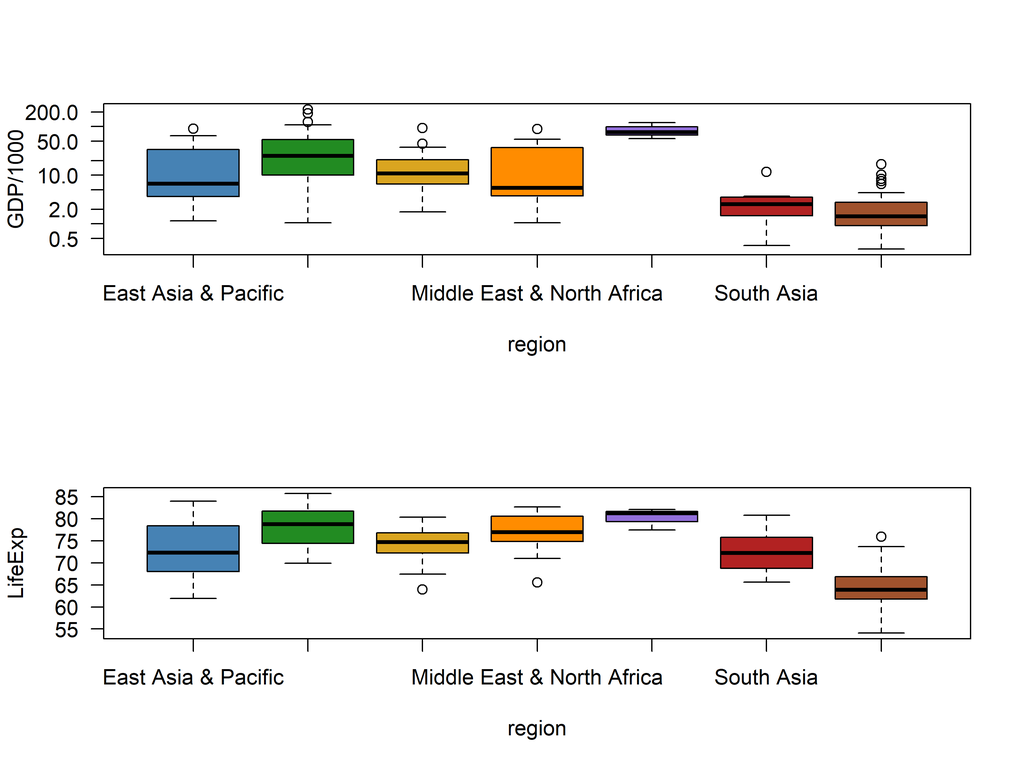

```r
par(mfrow = c(2,1))
boxplot(GDP/1000 ~ region, data = wdi, log = "y", las = 1, col = cols)
boxplot(LifeExp ~ region, data = wdi, las = 1, col = cols)
```

## Or prettier: modifying morgins with `oma` and `outer`

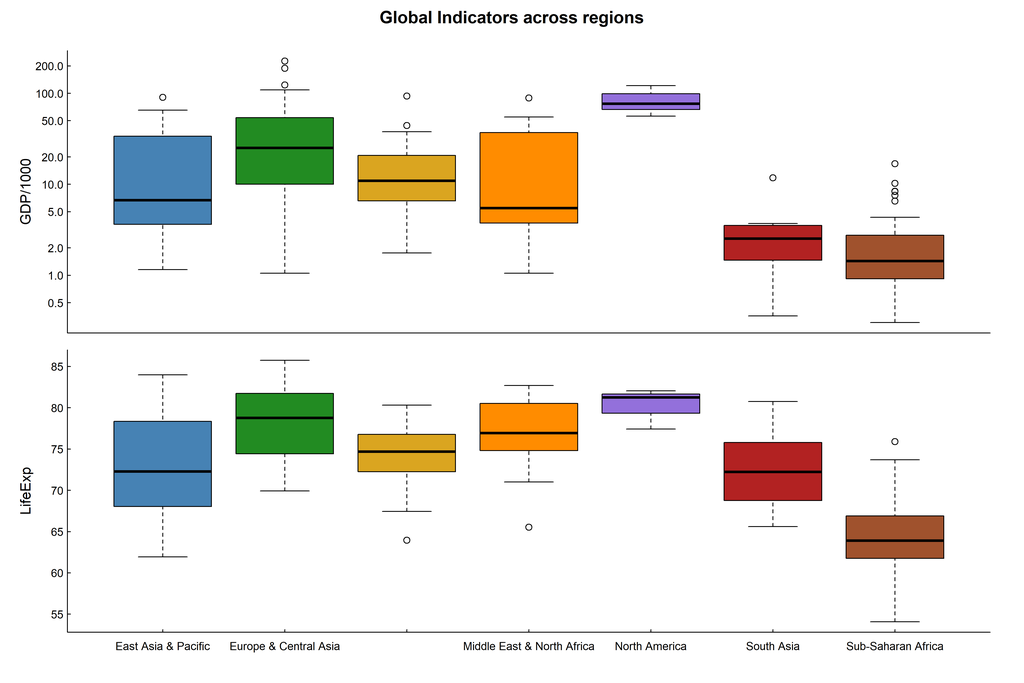

```r
par(mfrow = c(2,1),
    mar = c(0,4,1,2), # margins around each figure
    oma = c(3,0,2,0), # outer margins
    cex.axis = 0.8,
    tck = 0.01, bty ="l", mgp = c(2,.25,0))

boxplot(GDP/1000 ~ region, data = wdi, log = "y", las = 1,
        col = cols,
        xlab = "", xaxt = "n")
boxplot(LifeExp ~ region, data = wdi, las = 1, col = cols)
title("Global Indicators across regions", outer = TRUE)
```

## Issues with labelling?

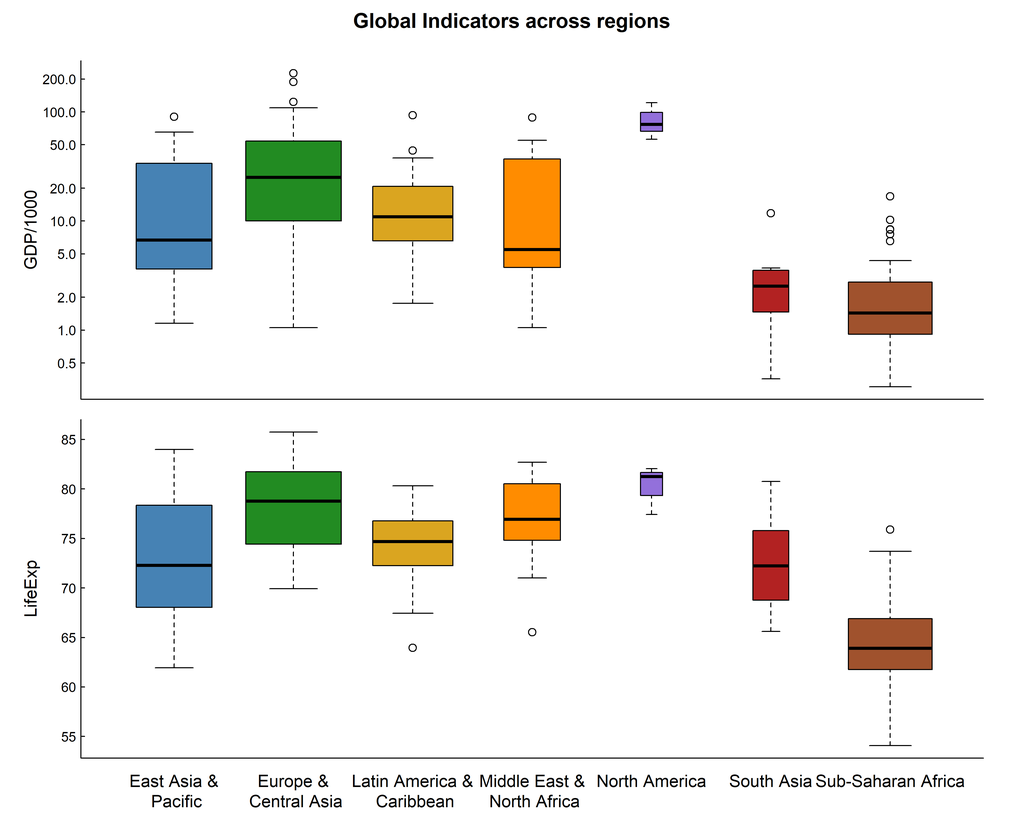

```r
par(mfrow = c(2,1),
    mar = c(0,4,1,2), # margins around each figure
    oma = c(3,0,2,0), # outer margins
    cex.axis = 0.8,
    tck = 0.01, bty ="l", mgp = c(2,.25,0))

boxplot(GDP/1000 ~ region, data = wdi, log = "y", las = 1, col = cols,
        varwidth = TRUE,
        xlab = "", xaxt = "n")  # no axis labelling
boxplot(LifeExp ~ region, data = wdi, las = 1,
        varwidth = TRUE,
        col = cols, xaxt = "n")
title("Global Indicators across regions", outer = TRUE)
regions <- levels(factor(wdi$region))
region_labels <- gsub("&", "&\n", regions, fixed = TRUE)
mtext(region_labels, side = 1, at = 1:7, line = 0, padj = 1)
```

## More complicated layouts with `layout`

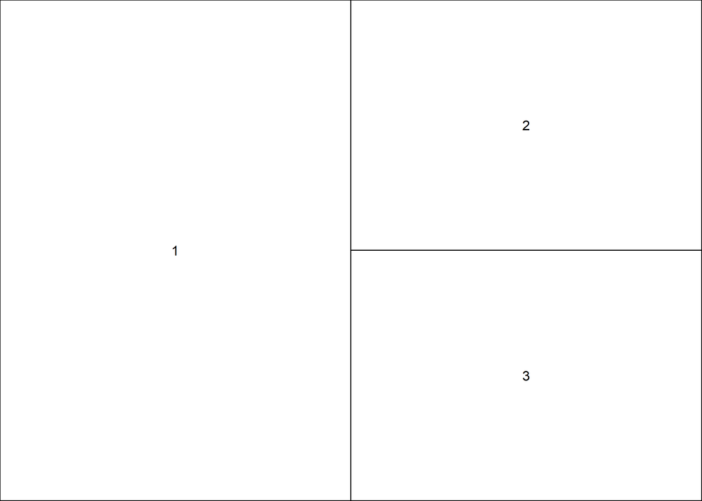

```r
layout(rbind(c(1,2), c(1,3)))
layout.show(3)
```

## Now do this:

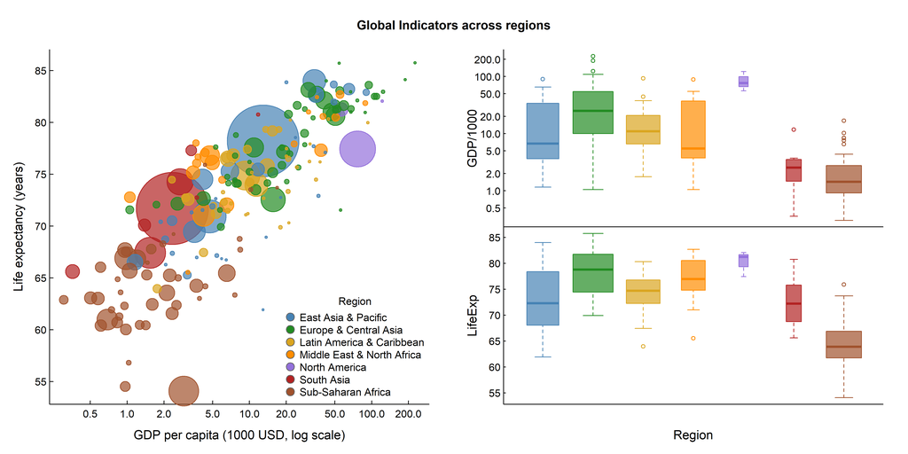

```r
require(scales)   # for transparency!
layout(rbind(c(1,2), c(1,3)))
par(cex.lab = 1.2, las = 1,
    mgp = c(2, .25, 0), tck = 0.01,
    bty = "l",  mar = c(0,4,0,2),
    oma = c(4,0,4,0), xpd = NA)

cont_col <- cols[match(wdi$region, levels(wdi$region))]
cex_pop  <- sqrt(wdi$Population / max(wdi$Population, na.rm = TRUE)) * 15

plot(wdi$GDP/1e3, wdi$LifeExp, log = "x",
     ylab = "Life expectancy (years)",
     xlab = "GDP per capita (1000 USD, log scale)", type = "n")
points(wdi$GDP/1e3, wdi$LifeExp,
       cex = cex_pop + .5, pch = 21, col = cont_col,
       bg  = alpha(cont_col, .7))
legend("bottomright", title = "Region",
       legend = levels(wdi$region),
       pt.bg = cols, col = "grey40",
       pch = 21, pt.cex = 1.8, bty = "n")

boxplot(GDP/1000 ~ region, data = wdi, log = "y", las = 1,
        varwidth = TRUE,
        col = alpha(cols, .7), border = cols,
        xlab = "", xaxt = "n")  # no axis labelling
boxplot(LifeExp ~ region, data = wdi, las = 1,
        varwidth = TRUE,
        col = alpha(cols, .7), border = cols,
        xaxt = "n", xlab = "Region")
title("Global Indicators across regions", outer = TRUE)
```

# 1b. Brief (unexpected) aside on functions

We’ll talk about functions more later in class. But one very basica pplication for using functions is bundling a bunch of code into a single quick line.

For example:

```r
setPars <- function(){
  par(cex.lab = 1.2, las = 1,
    mgp = c(2, .25, 0), tck = 0.01,
    bty = "l",  mar = c(0,4,0,2),
    oma = c(4,0,4,0), xpd = NA)
}


plotWDI <- function(){
  cont_col <- cols[match(wdi$region, levels(wdi$region))]
  cex_pop  <- sqrt(wdi$Population / max(wdi$Population, na.rm = TRUE)) * 15

  plot(wdi$GDP/1e3, wdi$LifeExp, log = "x",
       ylab = "Life expectancy (years)",
       xlab = "GDP per capita (1000 USD, log scale)", type = "n")
  points(wdi$GDP/1e3, wdi$LifeExp,
         cex = cex_pop + .5, pch = 21, col = cont_col,
         bg  = alpha(cont_col, .7))
  legend("bottomright", title = "Region",
         legend = levels(wdi$region),
         pt.bg = cols, col = "grey40",
         pch = 21, pt.cex = 1.8, bty = "n")
}

boxplotWDI <- function(){
  boxplot(GDP/1000 ~ region, data = wdi, log = "y", las = 1,
        varwidth = TRUE,
        col = alpha(cols, .7), border = cols,
        xlab = "", xaxt = "n")  # no axis labelling
  boxplot(LifeExp ~ region, data = wdi, las = 1,
          varwidth = TRUE,
          col = alpha(cols, .7), border = cols,
          xaxt = "n", xlab = "Region")
}
```

Note - these functions ONLY do the plotting - none of the setup. Also they have no arguments and they return nothing. They just do the thing. Code then becomes very simple:

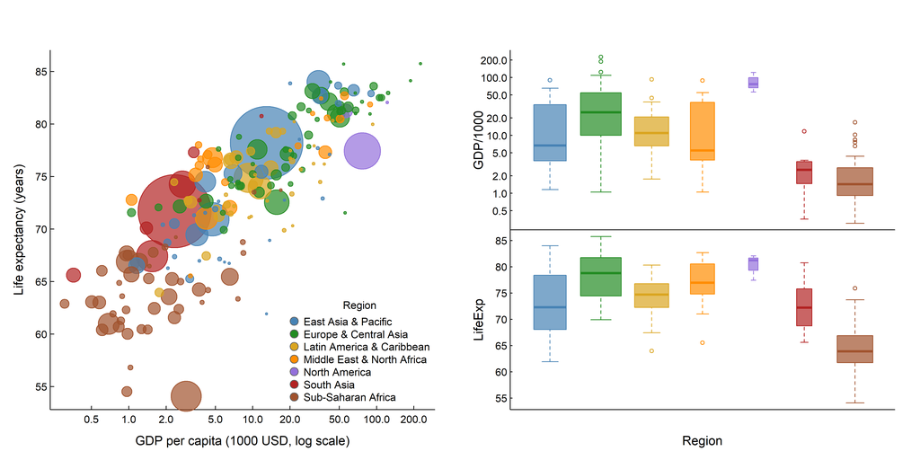

```r
layout(rbind(c(1,2), c(1,3)))
setPars()
plotWDI()
boxplotWDI()
```

# 2. Outputting figures to files

## What is a graphics device?

When R draws a plot, it sends output to a **graphics device** — a destination that knows how to render lines, points, text, and colors. By default that destination is your screen (the interactive device: `windows()` on Windows, `quartz()` on Mac). To save a figure to a file, you open a **file device** instead, draw your plot, then close the device with `dev.off()`. The pattern is always the same:

```r
device_function("filename.ext", width = ..., height = ...)  # open
  # ... plotting code ...
dev.off()                                                    # close and write
```

Nothing appears on screen — output goes straight to the file. Forgetting `dev.off()` is the most common mistake: the file stays open and incomplete.

## PDF vs. PNG: vector vs. raster

The two most useful formats are **PDF** (vector) and **PNG** (raster). They store images differently and suit different purposes.

|  | PDF | PNG |
| --- | --- | --- |
| Type | Vector | Raster (bitmap) |
| Stores images as | Mathematical shape descriptions | Grid of pixels |
| Scaling | Perfect at any size | Degrades if enlarged |
| Best for | Publications, LaTeX, print | Web, Word, presentations |
| Resolution setting | Not applicable | Critical — use `res =` |

**PDF** is resolution-independent: a line is stored as “from point A to point B,” so it renders crisp at any zoom level or print size. Ideal for journal submissions.

**PNG** stores a fixed pixel grid. At low resolution it looks blurry in print; at high resolution files get large. The `res` argument (dots per inch) controls the tradeoff.

## Exporting to PDF

```r
pdf("WDImegaplot.pdf", width = 12, height = 6)   # dimensions in inches

  layout(rbind(c(1,2), c(1,3)))
  setPars()
  plotWDI()
  boxplotWDI()

dev.off()
```

- `width` and `height` are always **inches**
- Default is `7 × 7` inches
- Plotting in a loop produces a **multi-page PDF** — one page per plot

## Exporting to PNG

```r
png("WDImegaplot.png", width = 2400, height = 1200, res = 200)   # pixels

  layout(rbind(c(1,2), c(1,3)))
  setPars()
  plotWDI()
  boxplotWDI()

dev.off()
```

- `width` and `height` are **pixels** by default
- `res` sets dots per inch — controls how large text and points appear relative to the canvas
- Effective plot size in inches = `width / res`, so `width = 800, res = 150` gives a ~5.3 × 4 inch plot
- For print quality use `res = 300`; for screen `res = 96` or `res = 150` is fine

## Controlling size in R Markdown

In an `.Rmd` file you don’t open and close devices manually — knitr handles that. Instead, control figure size through **chunk options**:

[output not shown]

- `fig.width` / `fig.height` — dimensions in **inches** (like PDF)
- `dpi` — resolution of the rendered PNG (knitr defaults to 72; use 150–300 for print)
- Set defaults for the whole document in the setup chunk:

```r
knitr::opts_chunk$set(fig.width = 7, fig.height = 5, dpi = 150)
```

## `jpeg()` — when to use it

`jpeg()` works identically to `png()` but uses lossy compression:

```r
jpeg("myplot.jpg", width = 800, height = 600, res = 150, quality = 90)
  # ... plotting code ...
dev.off()
```

- `quality` ranges 0–100; lower = smaller file, more compression artifacts
- Avoid for plots with sharp lines, text, or flat color regions — artifacts are visible
- Reasonable for photographic content or where file size is the priority

# 3. Introduction to `ggplot2`

## History and philosophy

`ggplot2` was created by Hadley Wickham in 2005, based on Leland Wilkinson’s book *The Grammar of Graphics* (1999) — hence the “gg”. The core idea is that every statistical graphic can be described by a small set of components assembled in a consistent way:

- **data** — a data frame
- **aesthetics** — mappings from variables to visual properties (x, y, color, size, …)
- **geometries** — the actual marks drawn (points, lines, bars, …)
- **scales**, **facets**, **themes** — further refinements

In base R, you build a plot by issuing a sequence of imperative commands (`plot()`, then `points()`, then `legend()`, …). In `ggplot2`, you *declare* what you want and the package figures out the rendering. The result is a single object you can inspect, modify, and print.

## Everything is built from data frames

This is the single most important constraint: **every variable you want to plot must be a column in a data frame**. You cannot pass a loose vector to `ggplot2` the way you can to `plot()`. This is sometimes inconvenient, but it forces a discipline that pays off with complex data.

```r
library(ggplot2)
wdi <- read.csv("WDI.csv")
wdi$region <- factor(wdi$region)
```

## Aesthetics and geoms

A `ggplot2` call has two required ingredients: `ggplot()` sets up the data and aesthetic mappings; a `geom_*()` function specifies what to draw.

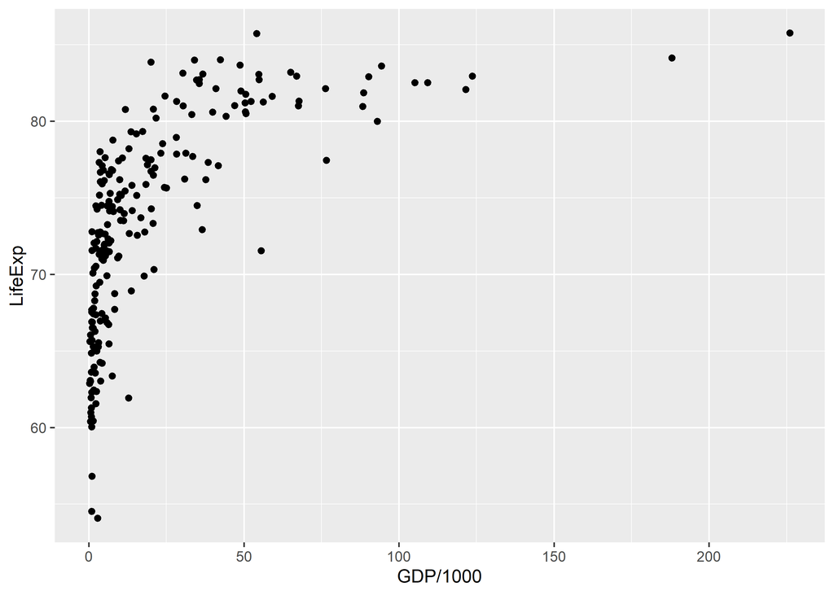

```r
ggplot(data = wdi, aes(x = GDP/1e3, y = LifeExp)) +
  geom_point()
```

`aes()` maps **variables** to **visual channels**:

| aesthetic | visual property |
| --- | --- |
| `x`, `y` | position |
| `color` | point/line color (outline) |
| `fill` | filled shape color |
| `size` | point size |
| `alpha` | transparency |
| `shape` | point character |

Common `geom_*` functions:

| geom | what it draws |
| --- | --- |
| `geom_point()` | scatter plot |
| `geom_line()` | lines connecting observations |
| `geom_smooth()` | smoothed trend with confidence band |
| `geom_boxplot()` | box-and-whisker |
| `geom_histogram()` | histogram |
| `geom_bar()` / `geom_col()` | bar chart |
| `geom_text()` | text labels |

## Advantage 1 — adding dimensions is quick

In base R, encoding a third or fourth variable requires computing color vectors, size scalings, and legend calls by hand. In `ggplot2`, you just add aesthetics — scales and legends are generated automatically.

Compare adding color, size, and a log scale:

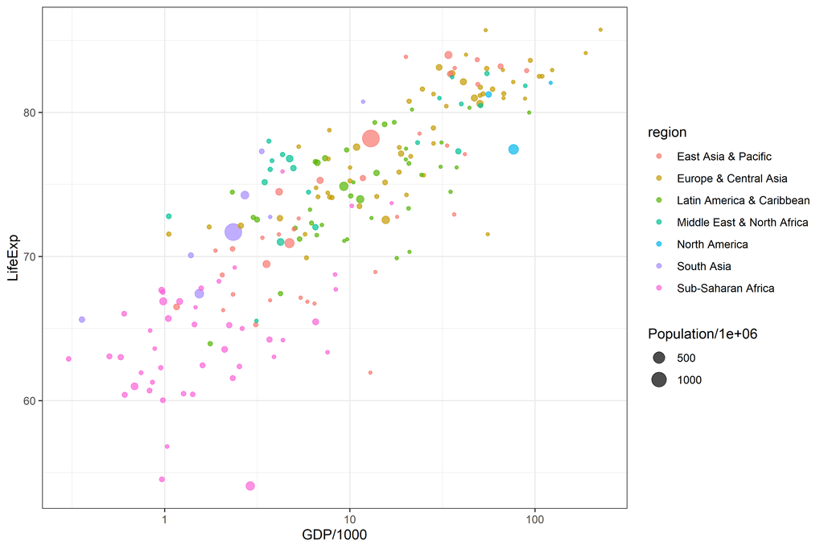

```r
ggplot(wdi, aes(x = GDP/1e3, y = LifeExp, color = region, size  = Population/1e6)) +
  geom_point(alpha = 0.7) +
  scale_x_log10() +
  theme_bw()
```

Four variables (GDP, life expectancy, region, population) in about 4 lines, with automatic legends for both color and size.

## BUT — it is extremely difficult to customize

`ggplot2`’s layered system makes common tasks easy but uncommon tasks surprisingly hard. Moving a legend to an exact coordinate, controlling tick positions on a secondary axis, mixing fonts within a plot title, nudging individual labels — all of these require either digging into `theme()` (which has ~100 arguments) or reaching for extension packages like `ggtext`, `ggnewscale`, or `ggrepel`.

In base R, arbitrary customization is usually a few `par()` arguments or a call to `text()` / `mtext()`. The same result in `ggplot2` may require a stack of overrides.

```r
# Moving legend inside the plot, changing its background,
# adjusting axis text size, removing the minor grid,
# and making the title left-aligned — all separate theme() calls
theme(
  legend.position      = c(0.15, 0.85),
  legend.background    = element_rect(fill = "white", color = "grey70"),
  axis.text            = element_text(size = 11),
  panel.grid.minor     = element_blank(),
  plot.title.position  = "plot"
)
```

> Customizing a ggplot is one of the better uses of Large-Language Models

## Faceting is extremely powerful / easy for data exploration

Faceting splits the data into subplots by one or more categorical variables — something that requires manual `layout()` calls and repeated plotting code in base R. In `ggplot2` it is a single line.

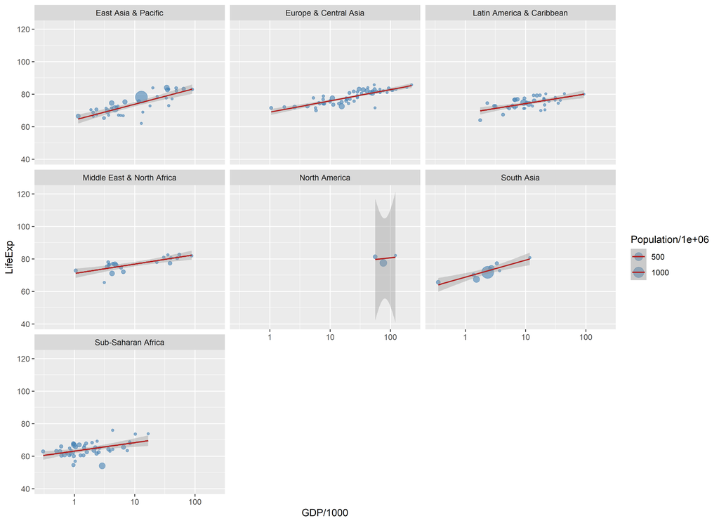

```r
ggplot(wdi, aes(x = GDP/1e3, y = LifeExp, size = Population/1e6)) +
  geom_point(alpha = 0.6, color = "steelblue") +
  geom_smooth(method = "lm", color = "firebrick",linewidth = 0.7) +
  scale_x_log10() +
  facet_wrap(~ region)   # key line of code
```

`facet_wrap(~ region)` produces one panel per region, all on the same scales, with a trend line in each. Doing this in base R would require a loop, careful margin management, and separate legend placement.

`facet_grid(rows ~ cols)` extends this to two categorical variables simultaneously.

The equivalent task in base R plotting is much harder.

## ggplot2 vs. base R: a summary

|  | base R | ggplot2 |
| --- | --- | --- |
| Learning curve | Steeper for basics | Steeper for customization |
| Multi-variable plots | Manual (but explicit) | Fast (automatic legends/scales) |
| Faceting | Manual `layout()` | `facet_wrap()` / `facet_grid()` |
| Fine-grained control | Excellent | Difficult |
| Default aesthetics | Minimal, print-friendly | Ugly (IMO) |
| Data requirement | Any form of data is OK | Data frame required |

The two approaches are complementary. `ggplot2` is often faster for exploratory work and for panel figures; base R is often better when you need precise, publication-ready control over every element.